Home: http://manmustbecool.github.io/MyWiki/

# 1 Networking in VM

Networking mode Overview:

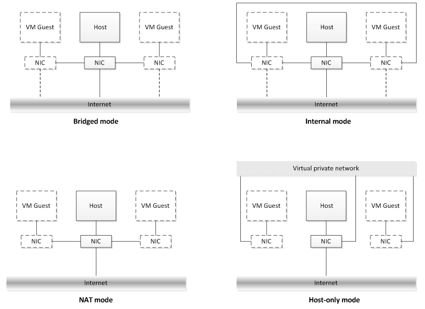

images_networking.png

- Bridged mode
  - The guest machine becomes a peer of all the other computers on that network virtualy. All network traffics will through the host network interface card (NIC). See the above picture, dot lines/links virtually connect guest machines’s NICs to the network, but solid lines conect all NICs representing real traffics.
- Internal mode
  - Similar to the bridged mode, but network traffics between guest machines can be hiden from the host machine NIC for a security reason (See above picture, the direct link between two guest machines).
- NAT (Network Address Translation) mode
  - The guest machine is sharing the Mac’s IP address of your Host machine.
- Host-only mode
  - The guest machine’s network world is wholly within your Host machine.

## 1.1 Bridged mode

- Disadvantages:
  1. Having troubles with accessing the network at all if your VM is not added to the domain.
  2. A generated mac address of the virtual machine is recognized by the company firewall

## 1.2 NAT mode

#### 1.2.0.1 VMware: Port forward with NAT setup

http://geekswithblogs.net/NewThingsILearned/archive/2009/11/13/connect-to-vmware-virtual-machines-using-remote-desktop.aspx

As the Hadoop uses SSH for node communications.

- Under the “Edit” Menu > “Virtual Network Editor”
- Click the “Add” for Port Forwarding
- Then add a port forwarding configuration. Forward incoming port 10000 to 22 for SSH

Now, we can SSH the guest machine with the host IP address with port 10000. e.g. ssh -p 10000 guestVMmachine

#### 1.2.0.2 VirtualBox: Port forward with NAT setup

Remote desktop connection on a Windows guest machine

The remote desktop must be enabled first in the guest machine (default is disabled in windows server 2008 [r2](https://code.google.com/p/bpaas/source/detail?r=2)).

- Add a port forwarding rule in VBox network setting. The 3389 is default port of remote desktop

  ```bash
  Rule1 TCP hostIp 3389 guestIp 3389
  ```

- The Windows server uses dynamic port for some services:

  ```bash
  # show the dynamic ports
  netsh int ipv4 show dynamicport tcp
  netsh int ipv6 show dynamicport udp
  # set the dynamic ports
  netsh int ipv4 set dynamicport tcp start=10000 num=1000
  netsh int ipv4 set dynamicport udp start=10000 num=1000
  ```

  In this case, multiple port forwarding can be simply done in VBox command line. (http://tombuntu.com/index.php/2008/12/17/configure-port-forwarding-to-a-virtualbox-guest-os/)

  ```bash
  $ VBoxManage setextradata "GuestVMName" "VBoxInternal/Devices/e1000/0/LUN#0/AttachedDriver/Config/DescriptiveName/Protocol" TCP
  $ VBoxManage setextradata "GuestVMName" "VBoxInternal/Devices/e1000/0/LUN#0/AttachedDriver/Config/DescriptiveName/GuestPort" 100
  $ VBoxManage setextradata "GuestVMName" "VBoxInternal/Devices/e1000/0/LUN#0/AttachedDriver/Config/DescriptiveName/HostPort" 100
  $ VBoxManage setextradata "GuestVMName" "VBoxInternal/Devices/e1000/0/LUN#0/AttachedDriver/Config/DescriptiveName/PortCount" 40
  ```

  The adapters are referred to by the following keys:
  - First PCNet: pcnet/0
  - Second PCNet: pcnet/1
  - First Intel PRO/1000: e1000/0
  - Second Intel PRO/1000: e1000/1
  - Third Intel PRO/1000: e1000/2

  Updating will be refected on the VM XML. `<ExtraDataItem name="VBoxInternal/D ...` will be added.

## 1.3 Host-only mode

#### 1.3.0.1 VirtualBox: Add hotst-only network

Go to File > Preferences > Network > Add host-only network. The DHCP can also be configured in here.

Reference site: http://communities.vmware.com/docs/DOC-2527

http://www.virtualbox.org/manual/ch06.html

# 2 Others

start vm in backgroup without GUI.

```bash
VBoxManage startvm $VM --type headless
# Windows
"C:/Program Files/Oracle VM VirtualBox/VBoxManage.exe" startvm ubuntu --type headless
```

To shut it down, request the shut down from the guest.

[Home Page](http://manmustbecool.github.io/MyWiki/)